# CAR-T QSP Model Validation

Layer 1 (numerical correctness) and Layer 2 (model sanity)

2026-06-07

# 1 Overview

This document works through a battery of validation checks for the corrected CAR-T QSP model. The goal is **not** to argue the model is right — it’s to rule out bugs so that downstream fitting against real data is interpretable.

Each check has an explicit pass criterion. If a check fails, the model (or the parameters, or the numerics) needs work before proceeding.

# 2 Model and baseline setup

# 3 Layer 1: Numerical correctness

Each check here is asking the same question in different ways: **is LSODA giving us the right answer, or is it giving us an artifact of step control?**

## 3.1 1.1 Tolerance convergence

Solve at three tolerance levels. Trajectories should be indistinguishable at the 3-digit level between the middle and tight settings. If they disagree, either tighten further or reformulate — the model has numerical issues.

```
##    state rel_err_medium_vs_tight rel_err_loose_vs_tight
## 1      E                1.78e-06               1.83e-04
## 2 T_high                1.27e-05               1.24e-03
## 3  T_mid                8.07e-06               1.56e-03
## 4  T_low                2.94e-06               4.13e-05
## 5  sBCMA                6.24e-07               1.15e-04
```

```
## T_high range (medium): -6.251635e-10 6e+10
```

```
## T_high range (tight): -3.824662e-12 6e+10
```

```
## [1] 30709.6
```

**Pass criterion:** `rel_err_medium_vs_tight` should be < 1e-3 for all states. Loose will usually be worse, which is fine — it’s there to show the scale of the effect.

# 4 Diagnostic: find when and where the tolerance mismatch happens

```
## Max rel err at time: 29.5 d
```

```
##   T_high (medium): 1.242e-09
```

```
##   T_high (tight):  -1.051e-12
```

```
##   Absolute error:  1.243e-09
```

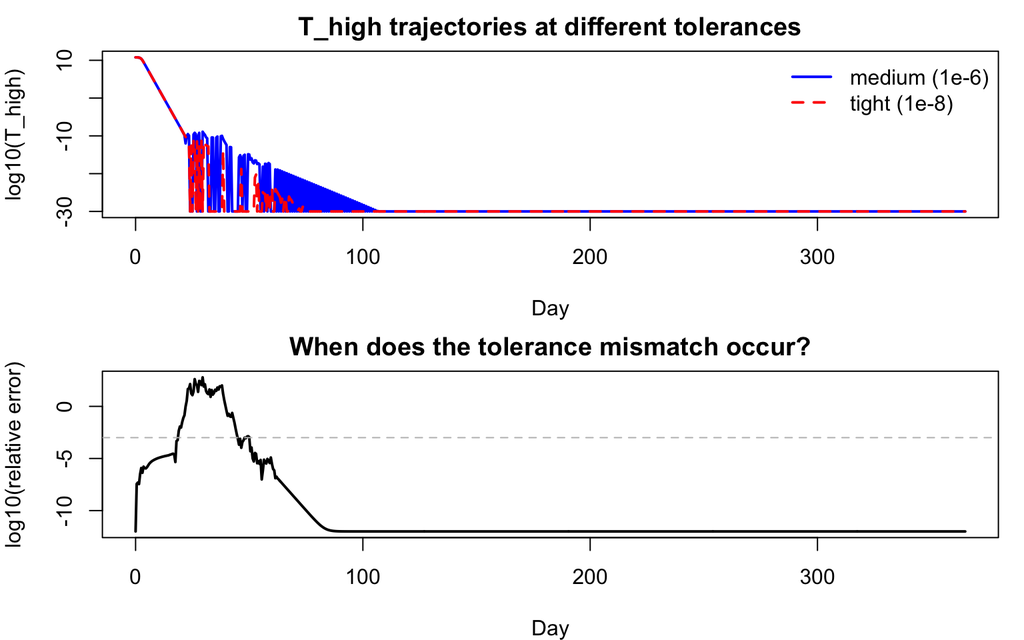

## 4.1 1.2 Method agreement

Solve with a completely different algorithm (`dop853`, an 8th-order explicit Runge-Kutta) and confirm agreement. Disagreement implies stiffness that one method handles and the other doesn’t, or a true algorithmic artifact.

```
##    state rel_err_lsoda_vs_dop
## 1      E             1.79e-06
## 2 T_high             1.42e-05
## 3  T_mid             8.92e-06
## 4  T_low             2.61e-06
## 5  sBCMA             5.29e-07
```

**Pass criterion:** relative error < 1e-3. If `dop853` chokes entirely (fails to solve), the system is stiff and you’re right to prefer LSODA — but then tolerance convergence (1.1) is doing the heavy lifting for validation.

## 4.2 1.3 Constraint checks

Confirm states that must be physically valid never aren’t.

```
##                         check result
## 1 T_total never exceeds K_max   TRUE
## 2            E never negative   TRUE
## 3       T_high never negative   TRUE
## 4        T_mid never negative   TRUE
## 5        T_low never negative   TRUE
## 6        sBCMA never negative   TRUE
## 7 LD monotonically decreasing   TRUE
```

**Pass criterion:** all `TRUE`. The 1e-6 tolerance allows for tiny negative excursions at the level of `atol` (LSODA doesn’t enforce positivity). Larger negatives indicate either loose tolerances or a formulation problem.

## 4.3 1.4 Event handling

The bolus at t=0 should deliver exactly 0.75e8 into E. Check the jump.

```
##     time         E
## 1 -0.001         0
## 2  0.000  75000000
## 3  0.001  75126362
## 4  0.500 170954687
## 5  1.000 376400827
```

**Pass criterion:** `E` should be essentially 0.75e8 at t just after dosing, modulo fast dynamics. If you see a value wildly off, the dose compartment or event spec is wrong.

# 5 Layer 2: Model sanity

Each subsection below is a controlled experiment where the expected answer is known. If the model doesn’t produce it, something is structurally wrong and fitting against real data will produce nonsense estimates.

## 5.1 2.1 Zero-dose control: tumor grows logistically

No CAR-T infused. Tumor should grow toward `K_max`, effectors stay at 0, sBCMA tracks the tumor.

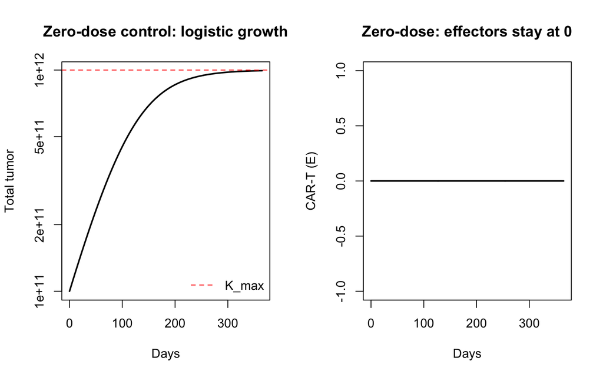

```
## Max |E| over 365 days: 0   (should be ~0)
```

```
## Final tumor / K_max: 0.9939569
```

**Pass criterion:** `max(|E|)` < 1e-6, tumor approaches (but doesn’t exceed) K_max. If tumor doesn’t grow meaningfully over a year at `k_prolif = 0.02` with no killing, check that `growth_factor` isn’t capping too aggressively.

## 5.2 2.2 No-tumor control: effector decay

Set tumor compartments to 0, infuse CAR-T. With no antigen signal, `expansion_drive` collapses to just `LD`, and `E` should decay roughly exponentially at `decay_rate`. We can fit an exponential to the late-time trajectory and recover `decay_rate`.

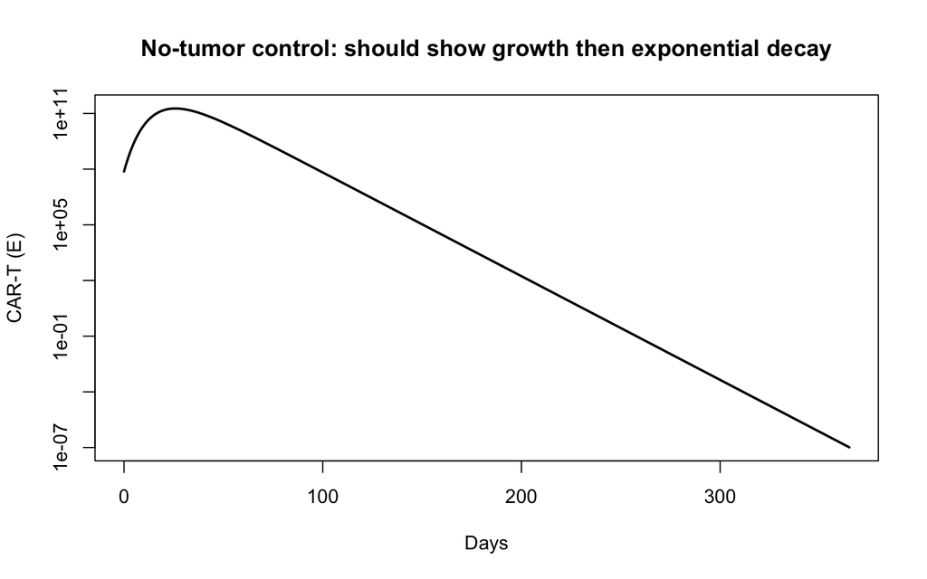

```
## Expected effective decay rate: 0.1287 /day
```

```
## Fitted decay rate (t > 60):    0.1285 /day
```

```
## Ratio fitted/expected:          0.998
```

**Pass criterion:** fitted decay rate within ~20% of expected. Discrepancy is fine if `LD` hasn’t fully decayed by t=60 (it has — `k_ld_recover = 0.08` gives half-life of ~8.7 days). Gross mismatch means the effector ODE isn’t what you think it is.

## 5.3 2.3 Antigen-density sweep: Hill function verification

Put all tumor in a single compartment and vary its antigen density. The initial kill rate at t=0⁺ (before expansion) should trace out the Hill function we specified. This directly checks the antigen pharmacology.

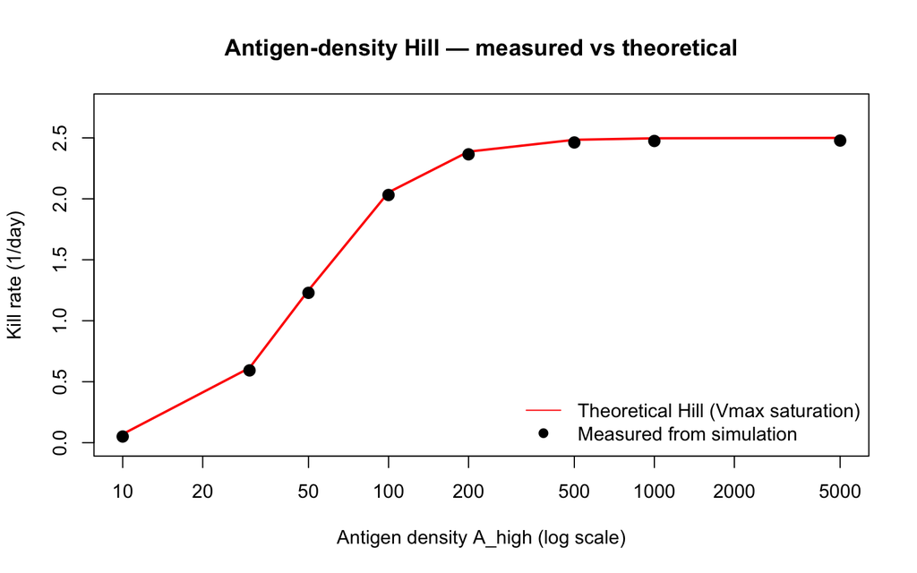

```
## Max rel error measured vs theoretical: 1.98
```

**Pass criterion:** points sit on the line (or very close — there’s some offset because E:T ratio isn’t quite saturated even at 1e12 dose). The shape must match: low at A=0, midpoint near EC50=50, plateau at high A.

## 5.4 2.4 E:T ratio sweep: new Hill function verification

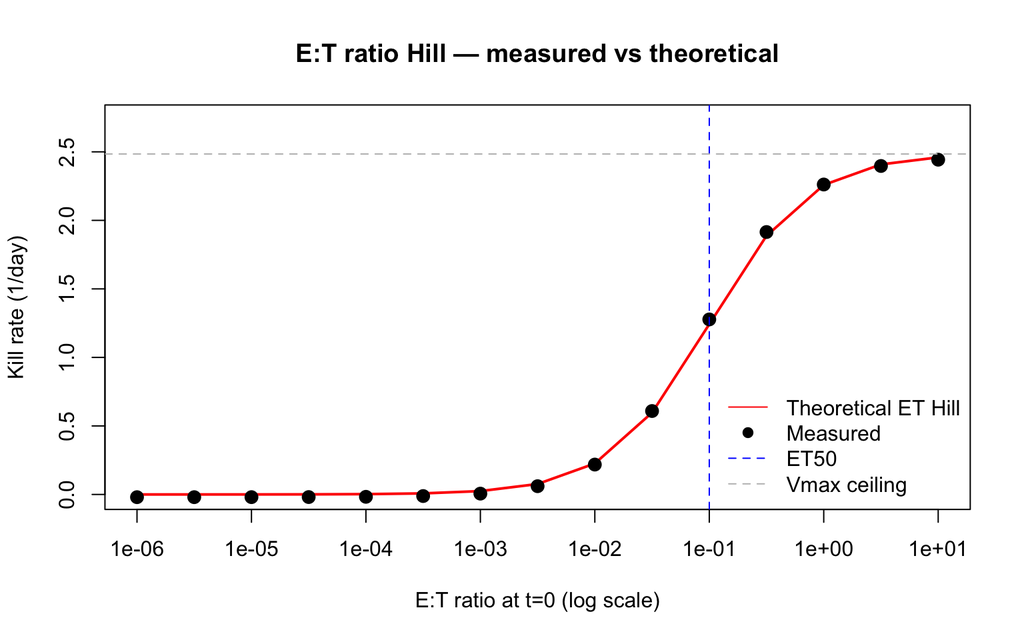

```
## Max rel error measured vs theoretical: 1.98
```

```
## Normalized max error: 0.009
```

**Pass criterion:** measured sigmoid with midpoint at `ET50 = 0.1` and plateau at `Vmax_A`. Confirms both Hill functions compose correctly.

## 5.5 2.5 sBCMA sink limiting case

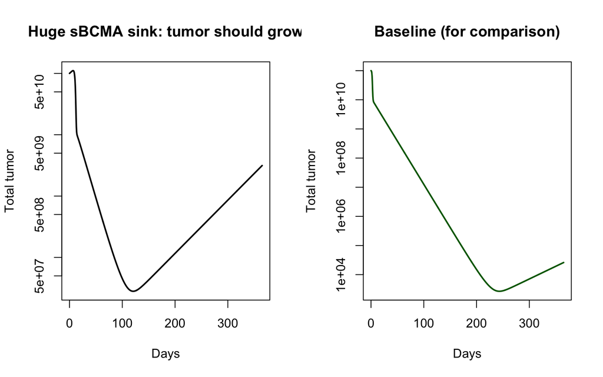

```
## Day 365 tumor with huge sink:     3.14e+09
```

```
## Day 365 tumor baseline:           2.61e+04
```

**Pass criterion:** with huge sBCMA, tumor grows substantially more than in baseline. If it doesn’t, the sink mechanism isn’t working as intended.

## 5.6 2.6 Timescale plausibility

Check that CAR-T peak timing and magnitude fall in the clinically reported range: peak at day 7–21, peak magnitude ~10³–10⁵× the infusion dose (in cells/µL terms — but since our E has ambiguous units, we check relative to the bolus amount).

```
## Peak E at day:               28.5   (clinical: 7-21)
```

```
## Peak E magnitude:            1.58e+13
```

```
## Fold expansion vs bolus:     2.11e+05   (clinical: 10^3 - 10^5)
```

```
## Post-peak half-life (days):  14
```

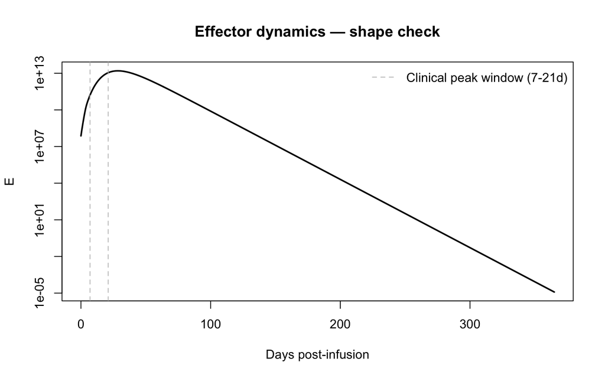

**Pass criterion:** peak in the 7–21 day window, fold expansion in the 10³–10⁵ range, detectable contraction. If the peak is on day 2 or day 60, `k_growth` or the `expansion_drive` structure needs revisiting.

# 6 Summary

| Layer | Check | What it rules out |
| --- | --- | --- |
| 1.1 | Tolerance convergence | Step-control artifacts |
| 1.2 | Method agreement | Stiffness / algorithm-specific bugs |
| 1.3 | Constraint checks | Physically impossible states |
| 1.4 | Event handling | Dosing misspecification |
| 2.1 | Zero-dose control | Background dynamics bugs |
| 2.2 | No-tumor control | Effector ODE bugs |
| 2.3 | Antigen Hill sweep | Antigen pharmacology structure |
| 2.4 | E:T Hill sweep | New E:T saturation structure |
| 2.5 | sBCMA sink limit | Shed-antigen mechanism |
| 2.6 | Timescale plausibility | Gross parameter misspec |

Once all checks pass, the forward simulator is trustworthy enough to build on — next steps are local/global sensitivity (Layer 3) and empirical validation against data (Layer 4).